# Act_report

## Introduction:

On this report I’m going to walk through all the insights I came up with on this project wrangling which are five insights, alongside with the visualization plot for each insight with a description below each plot.

The insights I came up with through this project are:

#### Insights:

- which stage is the more popular one?
- which source people usually use?
- which name is more used for the dogs?
- what is the most popular prediction?
- which rating_numerator are most used on the account?

##### First insight:

- which stage is more popular?

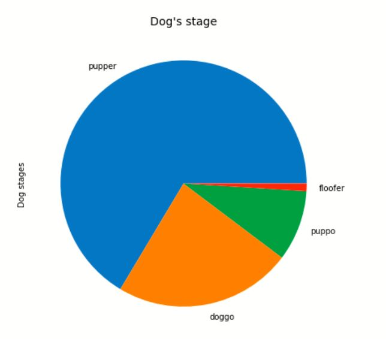

As you can see on the above plot I used ‘pie’ plot to visualize the dogs stage and the most common stage is the ‘pupper’ stage with a huge difference.

##### Second insight:

- which source people usually use?

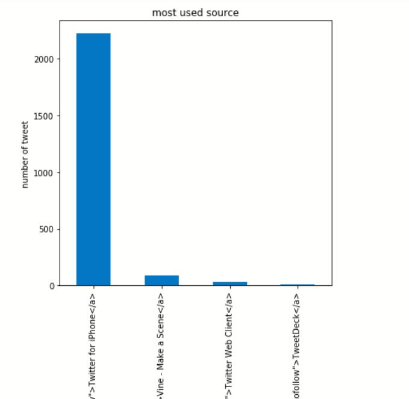

The majority of people use twitter with iPhone devices and the difference is huge.

##### Third insight:

- which name is more used?

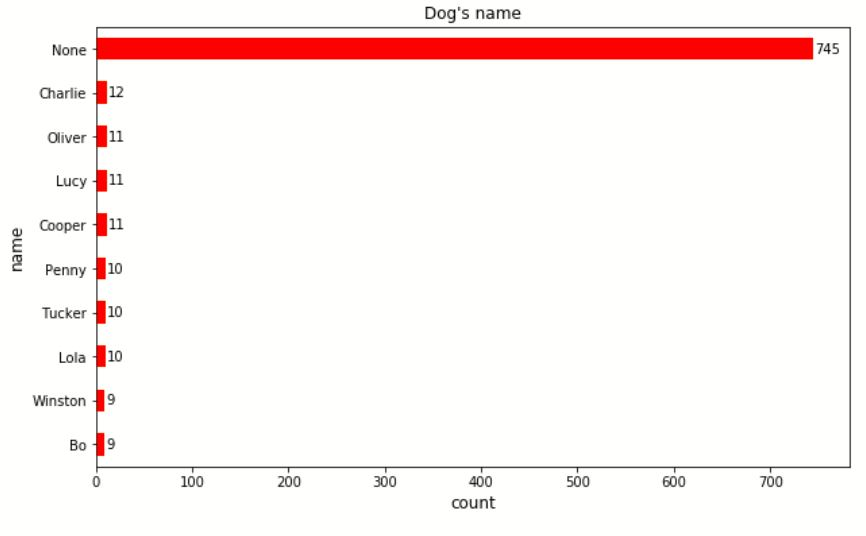

There are a lot of dogs with wrong names or unknown names on ‘WeRateDogs’ account.

##### Fourth insight:

- what is the most popular predection?

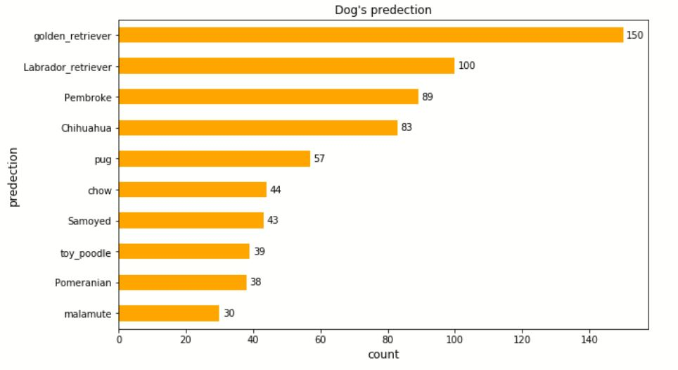

##### Fifth insight:

- which rating_numerator are most used?

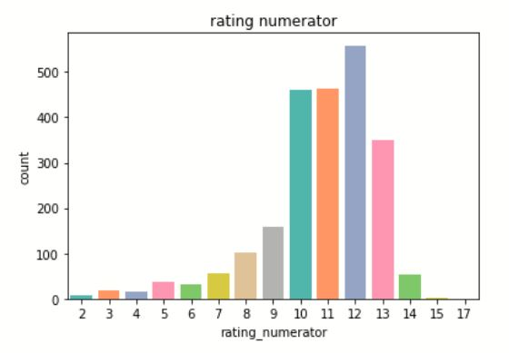

The above plot represents the rating numerator for the twitter account and as you can see most of the rating set between (10 to 13), but I think all the dogs should be at least above 9. Don’t you think?